# 07_Subanalyses

Chiara Draxler

24 1 2022

#Introduction for working code:

0. Download the Code from Github. The new downloaded folder hc_switch_cccu-main contains the R project, Rmd Code, created data frames, knitted Html Code, Figures as .pdf and.jpg, Preregistered synthetic Code, and a folder to store the downloaded RData called RData.

Name the folder appropriately (when downloading the code from GitHub the folder will be hc_switch_cccu-main).

1. Download data from https://www.icpsr.umich.edu/web/DSDR/studies/37067/datadocumentation

Attention! The downloaded project from GitHub does not contain any data files!

–> Click on Download, then select R, then follow the login –> store data in the folder specific to the R project in an extra sub-folder called RData (i.e., hc_switch_cccu-main - > RData). If you downloaded the code from GitHub, the RData folder will be already in the hc_switch_cccu-main projects folder.

–> Within the RData folder store data for wave 1 in DS0001, for wave 2 in DS0002 and so on (i.e., hc_switch_cccu-main - > RData -> DS0001 ). If you downloaded the code from GitHub, the relevant folders will be already there.

–> name the Rdata files according to the wave:

Wave 1: 37067-0001-Data (i.e., hc_switch_cccu-main - > RData -> DS0001 -> 37067-0001-Data.rda )

Wave 2: 37067-0002-Data (i.e., hc_switch_cccu-main - > RData -> DS0002 -> 37067-0002-Data.rda )

Wave 3: 37067-0003-Data (i.e., hc_switch_cccu-main - > RData -> DS0003 -> 37067-0003-Data.rda )

Wave 4: 37067-0004-Data (i.e., hc_switch_cccu-main - > RData -> DS0004 -> 37067-0004-Data.rda )

–> attention to the .rda ending when loading the data into R!

2. make sure to install all relevant packages before running the code!

All relevant packages and versions can be seen in the section “Analyses”

3. run the code according to the defined order beginning with 01_ (or 0 if you want to have a look at the synthetic data) and ending with 09_ so that all data frames are created appropriately
4. Run the Code :)

#1. Load Data

```r
load("cccu_SA.RData")
length(unique(cccu_SA$CASEID)) #women
```

```
## [1] 1226
```

#2. Load Packages

```r
library(lme4)
library(marginaleffects)
library(formr)
library(effects)
library(EValue)
library(psych)
library(dplyr)
library(tidyverse)
options(scipen=999)
```

#3. Models

##3.2 Model 2: including directly with contraceptive method associated predictors

DURATION and satisfaction!

```r
sa_m2 <- glmer(switch ~ contra_satis * hc_dur + (1| CASEID), family = binomial, data = cccu_SA, control=glmerControl(optimizer="bobyqa"))
```

```
## boundary (singular) fit: see ?isSingular
```

```r
summary(sa_m2)
```

```
## Generalized linear mixed model fit by maximum likelihood (Laplace
##   Approximation) [glmerMod]
##  Family: binomial  ( logit )
## Formula: switch ~ contra_satis * hc_dur + (1 | CASEID)
##    Data: cccu_SA
## Control: glmerControl(optimizer = "bobyqa")
##
##      AIC      BIC   logLik deviance df.resid
##   1936.4   1965.1   -963.2   1926.4     2279
##
## Scaled residuals:
##     Min      1Q  Median      3Q     Max
## -1.3320 -0.4414 -0.3871 -0.3283  4.5769
##
## Random effects:
##  Groups Name        Variance         Std.Dev.
##  CASEID (Intercept) 0.00000000000025 0.0000005
## Number of obs: 2284, groups:  CASEID, 1226
##
## Fixed effects:
##                     Estimate Std. Error z value    Pr(>|z|)
## (Intercept)          1.27267    0.46235   2.753     0.00591 **
## contra_satis        -0.69929    0.13380  -5.227 0.000000173 ***
## hc_dur              -0.12741    0.04874  -2.614     0.00894 **
## contra_satis:hc_dur  0.02260    0.01359   1.664     0.09621 .
## ---
## Signif. codes:  0 '***' 0.001 '**' 0.01 '*' 0.05 '.' 0.1 ' ' 1
##
## Correlation of Fixed Effects:
##             (Intr) cntr_s hc_dur
## contra_sats -0.973
## hc_dur      -0.794  0.762
## cntr_sts:h_  0.792 -0.798 -0.981
## optimizer (bobyqa) convergence code: 0 (OK)
## boundary (singular) fit: see ?isSingular
```

```r
confint(sa_m2, method = "Wald", level = .997)
```

```
##                          0.15 %     99.85 %
## .sig01                       NA          NA
## (Intercept)         -0.09945617  2.64480247
## contra_satis        -1.09635777 -0.30221858
## hc_dur              -0.27205273  0.01722621
## contra_satis:hc_dur -0.01771871  0.06291834
```

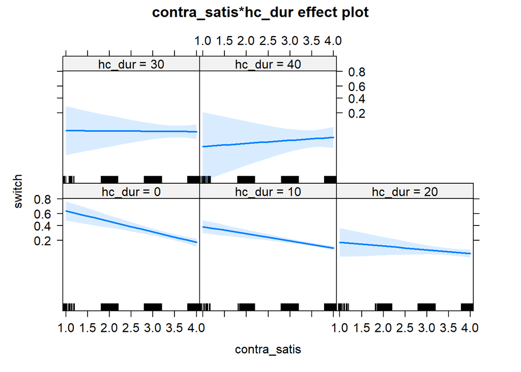

```r
plot(allEffects(sa_m2))
```

##3.3 Model 3: including not directly with contraceptive method associated predictors

```r
sa_m3 <- glmer(switch ~ contra_satis* hc_dur  +  sexual_satisfaction +  sex_freq + (1| CASEID), family = binomial, data = cccu_SA, control=glmerControl(optimizer="bobyqa"))
```

```
## boundary (singular) fit: see ?isSingular
```

```r
summary(sa_m3)
```

```
## Generalized linear mixed model fit by maximum likelihood (Laplace
##   Approximation) [glmerMod]
##  Family: binomial  ( logit )
## Formula: switch ~ contra_satis * hc_dur + sexual_satisfaction + sex_freq +
##     (1 | CASEID)
##    Data: cccu_SA
## Control: glmerControl(optimizer = "bobyqa")
##
##      AIC      BIC   logLik deviance df.resid
##   1938.7   1990.3   -960.4   1920.7     2275
##
## Scaled residuals:
##     Min      1Q  Median      3Q     Max
## -1.4669 -0.4405 -0.3790 -0.3199  4.5294
##
## Random effects:
##  Groups Name        Variance Std.Dev.
##  CASEID (Intercept) 0        0
## Number of obs: 2284, groups:  CASEID, 1226
##
## Fixed effects:
##                          Estimate Std. Error z value   Pr(>|z|)
## (Intercept)               0.95599    0.51809   1.845     0.0650 .
## contra_satis             -0.71028    0.13455  -5.279 0.00000013 ***
## hc_dur                   -0.12511    0.04877  -2.565     0.0103 *
## sexual_satisfaction       0.10394    0.05451   1.907     0.0566 .
## sex_freq2-5 times        -0.12103    0.17140  -0.706     0.4801
## sex_freq6-10 times       -0.21471    0.19073  -1.126     0.2603
## sex_freq11 or more times -0.39939    0.21601  -1.849     0.0645 .
## contra_satis:hc_dur       0.02209    0.01357   1.627     0.1037
## ---
## Signif. codes:  0 '***' 0.001 '**' 0.01 '*' 0.05 '.' 0.1 ' ' 1
##
## Correlation of Fixed Effects:
##             (Intr) cntr_s hc_dur sxl_st s_2-5t s_6-1t s_1omt
## contra_sats -0.830
## hc_dur      -0.710  0.759
## sxl_stsfctn -0.395 -0.072  0.013
## sx_frq2-5tm -0.120 -0.018 -0.018 -0.197
## sx_frq6-10t -0.027 -0.043 -0.052 -0.285  0.669
## sx_frq11omt -0.031 -0.002 -0.011 -0.323  0.604  0.578
## cntr_sts:h_  0.706 -0.795 -0.981 -0.008  0.019  0.044  0.012
## optimizer (bobyqa) convergence code: 0 (OK)
## boundary (singular) fit: see ?isSingular
```

```r
confint(sa_m3, method = "Wald", level = .997)
```

```
##                               0.15 %     99.85 %
## .sig01                            NA          NA
## (Intercept)              -0.58154872  2.49353483
## contra_satis             -1.10960405 -0.31095979
## hc_dur                   -0.26983092  0.01962026
## sexual_satisfaction      -0.05783874  0.26572284
## sex_freq2-5 times        -0.62969227  0.38763936
## sex_freq6-10 times       -0.78074371  0.35132585
## sex_freq11 or more times -1.04046483  0.24168047
## contra_satis:hc_dur      -0.01819468  0.06236477
```

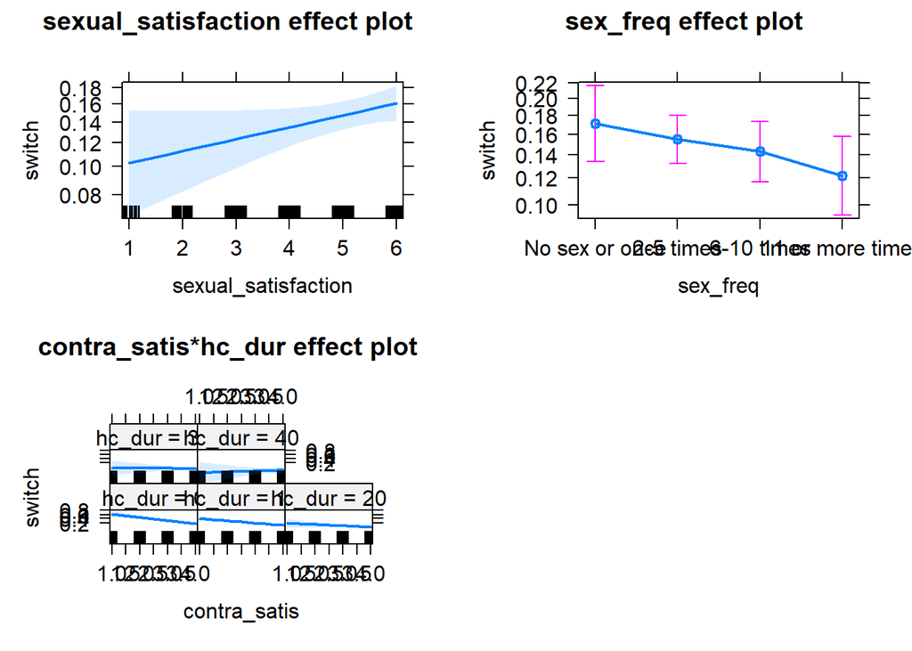

```r
plot(allEffects(sa_m3))
```

##3.4 Model 4: Controlling for observed selection effects

```r
#filter for first measurement occasion
length(unique(cccu_SA$CASEID))
```

```
## [1] 1226
```

```r
cccu_SA_sens = cccu_SA %>%
  group_by(CASEID) %>%
  arrange(WAVE) %>%
  mutate(count = row_number()) %>%
  ungroup()

cccu_SA_sens = cccu_SA_sens %>%
  filter(count == 1)

table(cccu_SA_sens$WAVE)
```

```
##
##   t1   t2   t3   t4
## 1032  135   59    0
```

```r
#repeating model 3 as linear model
sa_m3_lm <- glm(switch ~ contra_satis* hc_dur  +  sexual_satisfaction +  sex_freq, family = binomial, data = cccu_SA_sens)

summary(sa_m3_lm)
```

```
##
## Call:
## glm(formula = switch ~ contra_satis * hc_dur + sexual_satisfaction +
##     sex_freq, family = binomial, data = cccu_SA_sens)
##
## Deviance Residuals:
##     Min       1Q   Median       3Q      Max
## -1.6626  -0.6608  -0.5521  -0.4382   2.7958
##
## Coefficients:
##                          Estimate Std. Error z value  Pr(>|z|)
## (Intercept)               1.17708    0.64989   1.811    0.0701 .
## contra_satis             -0.67207    0.16880  -3.982 0.0000685 ***
## hc_dur                   -0.16593    0.10207  -1.626    0.1040
## sexual_satisfaction       0.12148    0.06841   1.776    0.0758 .
## sex_freq2-5 times        -0.46821    0.21279  -2.200    0.0278 *
## sex_freq6-10 times       -0.42825    0.23561  -1.818    0.0691 .
## sex_freq11 or more times -0.65051    0.26445  -2.460    0.0139 *
## contra_satis:hc_dur       0.02500    0.02818   0.887    0.3750
## ---
## Signif. codes:  0 '***' 0.001 '**' 0.01 '*' 0.05 '.' 0.1 ' ' 1
##
## (Dispersion parameter for binomial family taken to be 1)
##
##     Null deviance: 1195.3  on 1225  degrees of freedom
## Residual deviance: 1126.5  on 1218  degrees of freedom
## AIC: 1142.5
##
## Number of Fisher Scoring iterations: 4
```

```r
confint(sa_m3_lm, method = "Wald", level = .997)
```

```
##                                0.2 %     99.8 %
## (Intercept)              -0.74345654  3.1375732
## contra_satis             -1.18486474 -0.1759228
## hc_dur                   -0.48037382  0.1297577
## sexual_satisfaction      -0.07691590  0.3303963
## sex_freq2-5 times        -1.09448752  0.1734865
## sex_freq6-10 times       -1.12783773  0.2762344
## sex_freq11 or more times -1.44619195  0.1309183
## contra_satis:hc_dur      -0.05788075  0.1105397
```

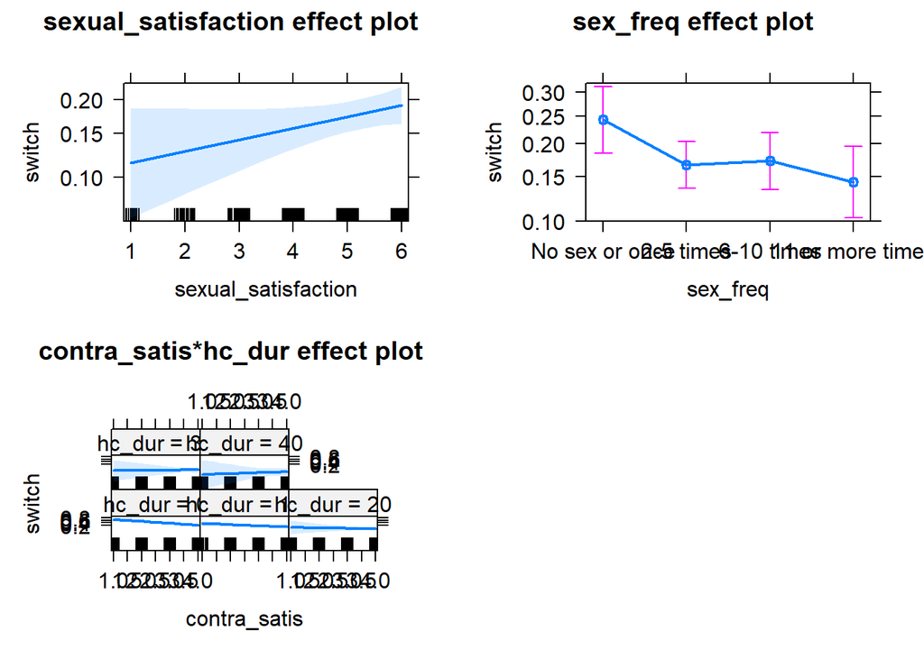

```r
plot(allEffects(sa_m3_lm))
```

```r
#model 4 as linear model (did not converge otherwise)

sa_m4_lm <- glm(switch ~ contra_satis*hc_dur +  sexual_satisfaction +   sex_freq + AGE + DEGREE_recode + POVRATE + HLTHPROB_recode + MEDPROB_recode + GAPINS_recode +
              TYPEINS_recode + NKIDS_t1 +  pregnant_between_waves + had_baby_between_waves+ Avoid_r + FEELPG_recode +
              rel_dur_factor,
            family = binomial,
            data = cccu_SA_sens)

summary(sa_m4_lm)
```

```
##
## Call:
## glm(formula = switch ~ contra_satis * hc_dur + sexual_satisfaction +
##     sex_freq + AGE + DEGREE_recode + POVRATE + HLTHPROB_recode +
##     MEDPROB_recode + GAPINS_recode + TYPEINS_recode + NKIDS_t1 +
##     pregnant_between_waves + had_baby_between_waves + Avoid_r +
##     FEELPG_recode + rel_dur_factor, family = binomial, data = cccu_SA_sens)
##
## Deviance Residuals:
##     Min       1Q   Median       3Q      Max
## -1.6764  -0.6425  -0.4723  -0.3156   3.0710
##
## Coefficients:
##                                                   Estimate  Std. Error z value
## (Intercept)                                      1.9391963   1.6170376   1.199
## contra_satis                                    -0.7282402   0.1790735  -4.067
## hc_dur                                          -0.2021649   0.1092619  -1.850
## sexual_satisfaction                              0.1349978   0.0735308   1.836
## sex_freq2-5 times                               -0.5006039   0.2302147  -2.175
## sex_freq6-10 times                              -0.4177540   0.2537456  -1.646
## sex_freq11 or more times                        -0.7358936   0.2900984  -2.537
## AGE                                              0.0206285   0.0210569   0.980
## DEGREE_recode7th/8th grade                       0.4824523   1.7026770   0.283
## DEGREE_recode9th grade                         -14.2604322 454.6517932  -0.031
## DEGREE_recode10th grade                          1.3394420   1.4230521   0.941
## DEGREE_recode11th grade                         -0.6642055   1.6364936  -0.406
## DEGREE_recode12th grade / no diploma             0.6542490   1.3865161   0.472
## DEGREE_recodehigh school diploma or equivalent   0.3881380   1.2338567   0.315
## DEGREE_recodesome college, no degree             0.4516728   1.2259155   0.368
## DEGREE_recodeassociate degree                   -0.2803433   1.2482201  -0.225
## DEGREE_recodebachelors degree                    0.3194279   1.2239296   0.261
## DEGREE_recodemasters degree                      0.3536238   1.2389597   0.285
## DEGREE_recodeprofessional or doctoral degree     0.4366632   1.3111201   0.333
## POVRATE                                         -0.0004147   0.0003940  -1.053
## HLTHPROB_recodeYes                               0.1588418   0.2064918   0.769
## MEDPROB_recodeYes                               -0.2213310   0.2771733  -0.799
## GAPINS_recodeYes                                -0.0522334   0.4056608  -0.129
## TYPEINS_recodeYes                               -0.0616307   0.4659470  -0.132
## NKIDS_t11                                       -0.0496493   0.2292086  -0.217
## NKIDS_t12                                        0.1901063   0.2617430   0.726
```

[output cut: 44 more lines]

```
## rel_dur_factor0q-25q                                 0.1836
## rel_dur_factor26q-50q                                0.3840
## rel_dur_factor51q-75q                                0.1793
## rel_dur_factor76q-100q                               0.9793
## contra_satis:hc_dur                                  0.2291
## ---
## Signif. codes:  0 '***' 0.001 '**' 0.01 '*' 0.05 '.' 0.1 ' ' 1
##
## (Dispersion parameter for binomial family taken to be 1)
##
##     Null deviance: 1195.3  on 1225  degrees of freedom
## Residual deviance: 1037.6  on 1189  degrees of freedom
## AIC: 1111.6
##
## Number of Fisher Scoring iterations: 14
```

```r
confint(sa_m4_lm, method = "Wald", level = .997)
```

[output not shown]

[output cut: 26 more lines]

[output not shown]

[output not shown]

[output cut: 164 more lines]

[output not shown]

```
##                                                         0.2 %          99.8 %
## (Intercept)                                      -4.251140838    6.4991346440
## contra_satis                                     -1.269975362   -0.1994472766
## hc_dur                                           -0.536852311    0.1157177621
## sexual_satisfaction                              -0.078860858    0.3589427544
## sex_freq2-5 times                                -1.179842508    0.1916971199
## sex_freq6-10 times                               -1.171799880    0.3398864573
## sex_freq11 or more times                         -1.610474930    0.1191667920
## AGE                                              -0.042704395    0.0826548905
## DEGREE_recode7th/8th grade                       -5.762481760    6.7127665828
## DEGREE_recode9th grade                         -262.241031039 -134.6303306161
## DEGREE_recode10th grade                          -2.599056511    7.2459255141
## DEGREE_recode11th grade                          -6.792835697    5.4586638813
## DEGREE_recode12th grade / no diploma             -3.146415382    6.5088498246
## DEGREE_recodehigh school diploma or equivalent   -2.870388993    6.0441546212
## DEGREE_recodesome college, no degree             -2.775747024    6.0993579400
## DEGREE_recodeassociate degree                    -3.591355665    5.3932477302
## DEGREE_recodebachelors degree                    -2.908091742    5.9631813969
## DEGREE_recodemasters degree                      -2.927072745    6.0146829580
## DEGREE_recodeprofessional or doctoral degree     -3.109959378    6.1871029872
## POVRATE                                          -0.001622512    0.0007256602
## HLTHPROB_recodeYes                               -0.470496596    0.7598635309
## MEDPROB_recodeYes                                -1.093377604    0.5653127604
## GAPINS_recodeYes                                 -1.400364340    1.0639946273
## TYPEINS_recodeYes                                -1.548808177    1.2692317411
## NKIDS_t11                                        -0.745336306    0.6194614929
## NKIDS_t12                                        -0.598918169    0.9594352707
## NKIDS_t13                                        -1.752264956    0.9295561503
## NKIDS_t14 or more                                -1.393158927    2.2621239359
## pregnant_between_wavesYes                        -2.514816448    2.6063196596
## had_baby_between_wavesYes                        -3.160860630    2.5658549643
## Avoid_r                                          -0.542539405   -0.1578123533
## FEELPG_recode                                    -0.144591071    0.2292367680
## rel_dur_factor0q-25q                             -0.387609795    1.0150828984
## rel_dur_factor26q-50q                            -0.516394556    0.9416255702
## rel_dur_factor51q-75q                            -0.454400429    1.1926746819
## rel_dur_factor76q-100q                           -1.077964865    1.0297836150
## contra_satis:hc_dur                              -0.052278783    0.1267352179
```

[figure not shown]

```r
plot(allEffects(sa_m4_lm))
```

###Average marginal effects ####m2

```r
#average marginal effect
ame <- marginaleffects(sa_m2)
summary(ame)
```

```
## Average marginal effects
##           Term    Effect Std. Error z value        Pr(>|z|)     2.5 %    97.5 %
## 1 contra_satis -0.062440   0.010554  -5.916 0.0000000032928 -0.083125 -0.041755
## 2       hc_dur -0.006383   0.001206  -5.291 0.0000001218775 -0.008748 -0.004018
##
## Model type:  glmerMod
## Prediction type:  response
```

####m3

```r
#average marginal effect
ame <- marginaleffects(sa_m3)
summary(ame)
```

```
## Average marginal effects
##                  Term                          Contrast    Effect Std. Error
## 1        contra_satis                             dY/dX -0.064283   0.010631
## 2              hc_dur                             dY/dX -0.006293   0.001206
## 3 sexual_satisfaction                             dY/dX  0.013350   0.006996
## 4            sex_freq        2-5 times - No sex or once -0.016695   0.024055
## 5            sex_freq       6-10 times - No sex or once -0.028787   0.026025
## 6            sex_freq 11 or more times - No sex or once -0.050567   0.027526
##   z value       Pr(>|z|)      2.5 %    97.5 %
## 1  -6.047 0.000000001477 -0.0851185 -0.043447
## 2  -5.218 0.000000180907 -0.0086563 -0.003929
## 3   1.908       0.056384 -0.0003632  0.027063
## 4  -0.694       0.487652 -0.0638428  0.030452
## 5  -1.106       0.268678 -0.0797961  0.022222
## 6  -1.837       0.066198 -0.1045166  0.003383
##
## Model type:  glmerMod
## Prediction type:  response
```

####m4

```r
#average marginal effect

ame <- marginaleffects(sa_m3_lm)
summary(ame)
```

```
## Average marginal effects
##                  Term                          Contrast   Effect Std. Error
## 1        contra_satis                             dY/dX -0.07591   0.014888
## 2              hc_dur                             dY/dX -0.01170   0.002663
## 3 sexual_satisfaction                             dY/dX  0.01760   0.009883
## 4            sex_freq        2-5 times - No sex or once -0.07502   0.035805
## 5            sex_freq       6-10 times - No sex or once -0.06933   0.039011
## 6            sex_freq 11 or more times - No sex or once -0.09937   0.040555
##   z value      Pr(>|z|)     2.5 %    97.5 %
## 1  -5.099 0.00000034224 -0.105090 -0.046729
## 2  -4.391 0.00001128148 -0.016915 -0.006475
## 3   1.780      0.074998 -0.001774  0.036966
## 4  -2.095      0.036142 -0.145200 -0.004847
## 5  -1.777      0.075551 -0.145786  0.007133
## 6  -2.450      0.014277 -0.178853 -0.019882
##
## Model type:  glm
## Prediction type:  response
```

```r
ame <- marginaleffects(sa_m4_lm)
summary(ame)
```

```
## Average marginal effects
##                      Term                                          Contrast
## 1            contra_satis                                             dY/dX
## 2                  hc_dur                                             dY/dX
## 3     sexual_satisfaction                                             dY/dX
## 4                sex_freq                        2-5 times - No sex or once
## 5                sex_freq                       6-10 times - No sex or once
## 6                sex_freq                 11 or more times - No sex or once
## 7                     AGE                                             dY/dX
## 8           DEGREE_recode                     7th/8th grade - 5th/6th grade
## 9           DEGREE_recode                         9th grade - 5th/6th grade
## 10          DEGREE_recode                        10th grade - 5th/6th grade
## 11          DEGREE_recode                        11th grade - 5th/6th grade
## 12          DEGREE_recode           12th grade / no diploma - 5th/6th grade
## 13          DEGREE_recode high school diploma or equivalent - 5th/6th grade
```

[output cut: 61 more lines]